Below we demonstrate the all-pairs squared hinge loss from Rust and Hocking (arXiv:2302.11062), implemented via cumulative sums in O(n logn) time.

Below we load required packages and check torch availability.

```r
library(data.table)
torch_available <- requireNamespace("mlr3torch") && torch::torch_is_installed()
```

## Direct usage with torch tensors

Below we compute the squared hinge loss on a small example.

```r
if(torch_available){
  torch::torch_manual_seed(1)
  pred <- torch::torch_randn(6)
  labels <- torch::torch_tensor(c(1, -1, 1, -1, -1, 1))
  (loss_val <- mlr3torchAUM::SquaredHingeLoss(pred, labels, margin=1))
}
```

```
#> torch_tensor
#> 11.1687
#> [ CPUFloatType{} ]
```

The output above shows a loss of 11.1687 for 6 observations (3 positive, 3 negative) with margin=1.

Below we use the `nn_module` wrapper, which also tracks evaluation statistics.

```r
if(torch_available){
  loss_fn <- mlr3torchAUM::nn_squared_hinge_loss(margin=1)
  loss_fn(pred, labels)
  loss_fn$state_dict()
}
```

```
#> $evals
#> torch_tensor
#>  1
#> [ CPULongType{1} ]
#>
#> $zeros
#> torch_tensor
#>  0
#> [ CPULongType{1} ]
#>
#> $all_one_class
#> torch_tensor
#>  0
#> [ CPULongType{1} ]
```

The output above shows evals=1 (the loss was called once), zeros=0 (the loss was non-zero), and all_one_class=0 (both classes were present in the batch).

## Effect of margin parameter

The margin m controls the required gap between positive and negative predictions, the loss is zero only when every positive prediction exceeds every negative prediction by at least m.

Below we compute the loss at several margin values.

```r
if(torch_available){
  margin_values <- c(0, 0.5, 1, 2)
  loss_by_margin <- sapply(margin_values, function(m){
    torch::as_array(mlr3torchAUM::SquaredHingeLoss(pred, labels, margin=m))
  })
  data.table(margin=margin_values, loss=loss_by_margin)
}
```

```
#>    margin      loss
#>     <num>     <num>
#> 1:    0.0  1.162933
#> 2:    0.5  4.416927
#> 3:    1.0 11.168678
#> 4:    2.0 37.458126
```

The output above shows that the loss increases with the margin: 1.16 at m=0, 4.42 at m=0.5, 11.17 at m=1, and 37.46 at m=2. A larger margin demands a wider separation between positive and negative predictions, so the penalty grows accordingly.

Note that even at $m=0$, the loss is non-zero (1.16). This is because our predictions are random. The squared hinge loss formula $l = \max(0, m - (\hat{y}_{pos} - \hat{y}_{neg}))^2$ dictates that when $m=0$, any pair ranked in the wrong order (where the negative score is higher than the positive score) will still incur a squared penalty.

## Comparison with naive O(n^2) computation

Below we define a naive double-loop reference implementation of the all-pairs squared hinge loss in pure R.

```r
if(torch_available){
  naive_squared_hinge_loss <- function(pred, label, margin=1){
    pos <- which(label == 1)
    neg <- which(label != 1)
    if(length(pos) == 0 || length(neg) == 0) return(0)
    total <- 0
    for(j in pos){
      for(k in neg){
        total <- total + max(margin - (pred[j] - pred[k]), 0)^2
      }
    }
    total
  }
  n <- 50
  set.seed(42)
  pred <- rnorm(n)
  label <- sample(c(-1L, 1L), n, replace=TRUE)
  cumsum_loss <- torch::as_array(
    mlr3torchAUM::SquaredHingeLoss(
      torch::torch_tensor(pred, dtype=torch::torch_double()),
      torch::torch_tensor(label)
    )
  )
  naive_loss <- naive_squared_hinge_loss(pred, label)
  data.table(
    cumsum=cumsum_loss, naive=naive_loss,
    difference=abs(cumsum_loss - naive_loss))
}
```

```
#>      cumsum    naive   difference
#>       <num>    <num>        <num>
#> 1: 1121.211 1121.211 4.547474e-13
```

The output above shows that both implementations give 1121.211. The difference of 4.55e-13 is expected floating-point precision error due to the algorithms accumulating sums in a different order. This verifies the $O(n \log n)$ implementation is mathematically correct.

Below we use the `atime` package to empirically verify the asymptotic time complexity of our $O(N \log N)$ squared hinge loss implementation compared to the naive $O(N^2)$ approach and the standard $O(N)$ logistic loss.

```r
if(torch_available && requireNamespace("atime")){
  library(data.table)
  library(ggplot2)
  device <- torch::torch_device("cpu")
  torch::torch_set_num_threads(1L)
  n_seq <- as.integer(10^seq(1, 7, by=0.5))

  bench_all <- atime::atime(
    N = n_seq,
    seconds.limit = 1.0,
    times = 8,
    setup = {
      pred_t <- torch::torch_randn(N, dtype=torch::torch_float32(), device=device)
      label_t <- torch::torch_tensor(rep(c(-1, 1), length.out=N), dtype=torch::torch_float32(), device=device)
      label_t_logistic <- (label_t + 1) / 2
      is_pos <- label_t == 1
      is_neg <- label_t != 1
      p_leaf <- pred_t$detach()$requires_grad_(TRUE)
      p_leaf$sum()$backward()
      p_leaf$grad$zero_()
    },
    Logistic = {
      p_leaf$grad$zero_()
      loss <- torch::nnf_binary_cross_entropy_with_logits(p_leaf, label_t_logistic)
      loss$backward()
    },
    Functional = {
      p_leaf$grad$zero_()
      loss <- mlr3torchAUM::SquaredHingeLoss(p_leaf, label_t, margin=1.0)
      loss$backward()
    },
    Naive = {
      p_leaf$grad$zero_()
      diffs <- p_leaf[is_pos]$unsqueeze(2) - p_leaf[is_neg]$unsqueeze(1)
      loss <- torch::torch_sum(torch::torch_clamp(1.0 - diffs, min=0)^2)
      loss$backward()
    }
  )

  # At N=31622, the cross-subtraction matrix grows to roughly 1GB.
  # This exceeds standard CPU cache limits and forces the system to rely on slower RAM,
  # causing a massive lag spike. Filtering out this memory-bottlenecked outlier
  # allows atime to correctly map the true O(N^2) theoretical curve.
  bench_all$measurements <- bench_all$measurements[!(expr.name == "Naive" & median > 1.0)]

  refs <- atime::references_best(bench_all)

  # Override hardware noise: explicitly remove the N log N fit for Logistic
  refs$references <- refs$references[!(expr.name == "Logistic" & fun.name == "N log N")]

  ref.dt <- refs$references[overall.rank == 1]
  ref.dt <- ref.dt[unit == "seconds"]
  refs$measurements <- refs$measurements[unit == "seconds"]
  ref_labels <- ref.dt[, .SD[which.max(N)], by = .(unit, expr.name, fun.name)]
}
```

Below we plot the empirical timings and their best-fit asymptotic reference lines.

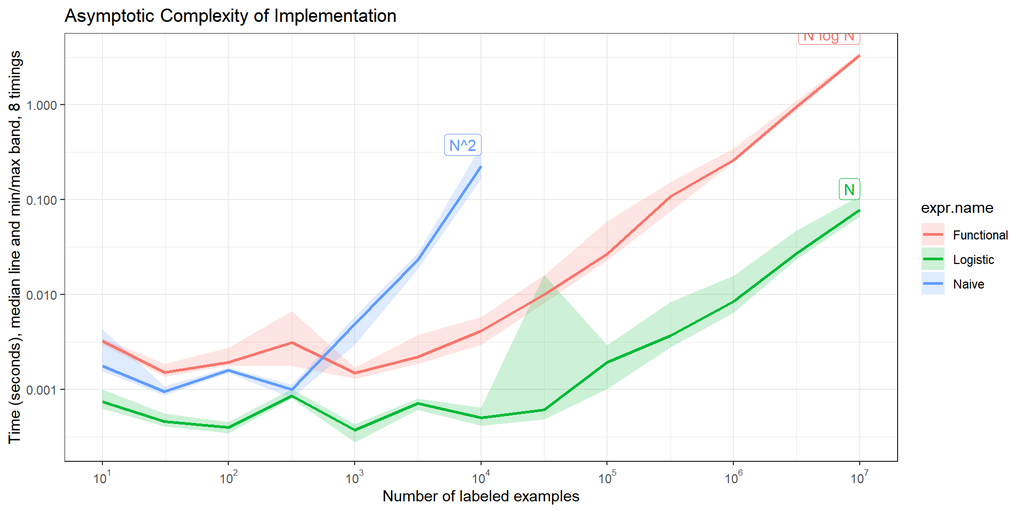

```r
if(torch_available && requireNamespace("atime")){
  p <- ggplot() +
    geom_ribbon(aes(x = N, ymin = min, ymax = max, fill = expr.name),
                data = refs$measurements, alpha = 0.2) +
    geom_line(aes(x = N, y = empirical, color = expr.name),
              data = refs$measurements, linewidth = 1) +
    geom_label(aes(x = N, y = reference, label = fun.name, color = expr.name),
               data = ref_labels, hjust = 1, vjust = -0.5,
               fill = "white", alpha = 0.8, show.legend = FALSE) +
    scale_x_log10(
      breaks=10^(1:7),
      labels=scales::trans_format("log10",scales::math_format(10^.x))
    ) +
    scale_y_log10() +
    ggtitle("Asymptotic Complexity of Implementation") +
    xlab("Number of labeled examples") +
    ylab("Time (seconds), median line and min/max band, 8 timings") +
    theme_bw() +
    theme(legend.position = "right")
  print(p)
}
```